# Less Volume, More Creativity

CVC 2017

## A note about these slides

The support for documentation creation in RStudio is great.

- These slides are HTML, but I created them in RMarkdown (+ a little bit of HTML fiddling)
- A single RMarkdown file can generate PDF, HTML, or Word
- No need to know HTML, LateX or Word
- But if you do, you can take advantage
- You will learn about RMarkdown later today

## Less Volume, More Creativity

## Less Volume, More Creativity

## Mike McCarthy

Head coach, Green Bay Packers (NFL Football)

- Packers subscribe to "draft and develop"
- Among the youngest teams in the league every year
- Coaching staff constantly teaching young players

## Mike McCarthy

Head coach, Green Bay Packers (NFL Football)

- Packers subscribe to "draft and develop"
- Among the youngest teams in the league every year
- Coaching staff constantly teaching young players

**Joe from Fitchburg, WI:**

> Do you have a favorite Mike McCarthy quote?

## Mike McCarthy

Head coach, Green Bay Packers (NFL Football)

- Packers subscribe to "draft and develop"
- Among the youngest teams in the league every year
- Coaching staff constantly teaching young players

**Joe from Fitchburg, WI:**

> Do you have a favorite Mike McCarthy quote? Mine is "statistics are for losers".

## Mike McCarthy

Head coach, Green Bay Packers (NFL Football)

- Packers subscribe to "draft and develop"
- Among the youngest teams in the league every year
- Coaching staff constantly teaching young players

**Joe from Fitchburg, WI:**

> Do you have a favorite Mike McCarthy quote? Mine is "statistics are for losers".

**Vic Ketchman (packers.com):**

> "Less volume, more creativity."

Source: [Ask Vic @ packers.com](http://www.packers.com/news-and-events/article-ask-vic/article-1/Half-line-drills-best-thing-about-training-camp/a6cca4ae-7e15-4fb5-a32f-4a066340eb18#ixzz3dqBGgs7b)

## More Mike McCarthy Quotes

You’ve got to watch that you **don’t do too much**. We have a philosophy on our coaching staff about **less volume, more creativity**.

A lot of times you end up putting in a lot more volume, because you are teaching fundamentals and you are teaching concepts that you need to put in, but you may not necessarily use because they are building blocks for other concepts and variations that will come off of that … **In the offseason you have a chance to take a step back and tailor it more specifically towards your team and towards your players.**"

## More Mike McCarthy Quotes

**Q.** (for McCarthy) How many offensive and defensive plays might you have coming into a game on average?

**A.** That's an excellent question because years ago when I first got into the NFL we had 150 passes in our game plan. I've put a sign on all of the coordinators' doors - **less volume, more creativity**. We function with more concepts with less volume. We're more around 50 (passes) into a game plan.

Source: http://www.jsonline.com/packerinsider/106968233.html (Nov 10, 2010)

## The Minimal R Exercise

**List** every R command used throughout a course

**Organize** by syntactic similarity and by purpose

**Scratch** everything you could have done without

**Replace** dissimilar tools with more similar tools

**Aim** for a set of commands that is

- **small**: fewer is better
- **coherent**: commands should be as similar as possible
- **powerful**: can do what needs doing

**Result:** [Minimal R for Intro Stats](https://github.com/ProjectMOSAIC/mosaic/blob/master/vignettes/MinimalR.pdf)

## Less Volume, More Creativity

It is not enough to use R, it must be used efficiently and elegantly.

The `mosaic` package attempts to be part of one solution.

Perfection is achieved, not when there is nothing more to add, but when there is nothing left to take away.  
— Antoine de Saint-Exupery (writer, poet, pioneering aviator)

## Introductory Tutorial

We're going to see an example of using a Less Volume, More Creativity Approach in a [Tutorial on US Births](http://dtkaplan.shinyapps.io/USBirths)

You can come back later and

- look at slides that go through essentially the same information
- jump ahead to what comes after the US Births example

## The Most Important Template

## **goal ( yyy ~ xxx , data = mydata )**

## The Most Important Template

## **goal ( y ~ x , data = mydata )**

## The Most Important Template

## **goal ( y ~ x , data = mydata , …)**

### Other versions:

```r
# simpler version
goal( ~ x, data = mydata )
# fancier version
goal( y ~ x | z , data = mydata )
# unified version
goal( formula , data = mydata )
```

## 2 Questions

## **goal ( y ~ x , data = mydata )**

### What do you want R to do? (goal)

### What must R know to do that?

## 2 Questions

## **goal ( y ~ x , data = mydata )**

### What do you want R to do? (goal)

- This determines the function to use

### What must R know to do that?

- This determines the inputs to the function
- Must identify the variables and data frame

## How do we make this plot?

## How do we make this plot?

### What is the Goal?

### What does R need to know?

## How do we make this plot?

### What is the Goal?

- a plot with points

### What does R need to know?

- which variable goes where
- which data set

## How do we tell R to make this plot?

### What is the Goal?

- a plot with points (`gf_point()`)

### What does R need to know?

- which variable goes where (`births ~ dayofyear`)
- which data set (`data = Births78`)
  - use `?Births78` for documentation

## How do we make this plot?

## **goal ( y ~ x , data = mydata )**

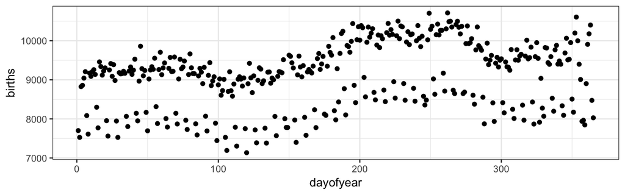

```r
gf_point( births ~ dayofyear, data = Births78)
```

### Two Questions?

1. Command: `gf_boxplot()`
2. The data: `HELPrct`
- Variables: `age`, `substance`
- use `?HELPrct` for info about data

## Your turn: How do you make this plot?

```r
gf_boxplot(age ~ substance, data = HELPrct)
```

[output not shown]

## Graphical Summaries: One Variable

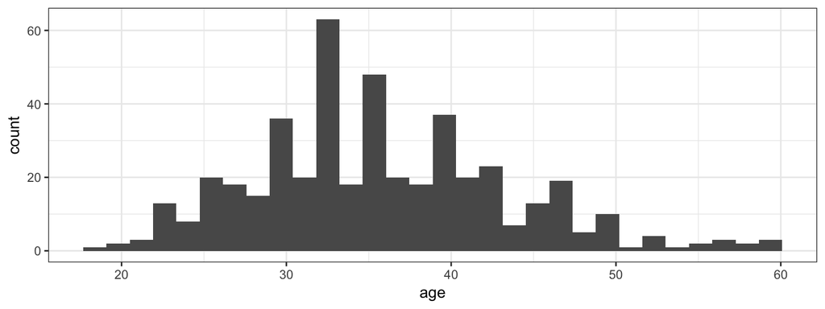

```r
gf_histogram( ~ age, data = HELPrct)
```

Note: When there is **one variable** it is on the **right side** of the formula.

## Graphical Summaries: One Variable

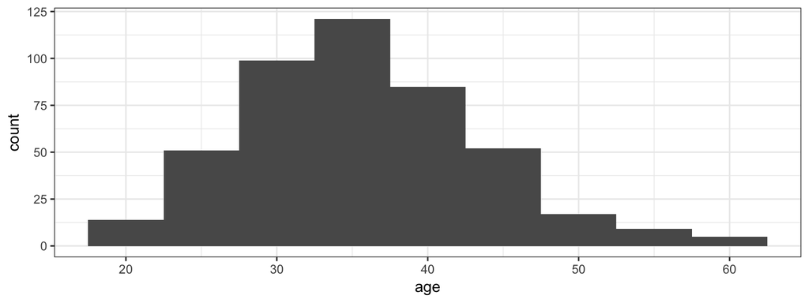

```r
gf_histogram( ~ age, data = HELPrct, binwidth = 5)
```

Note: When there is **one variable** it is on the **right side** of the formula.

## Graphical Summaries: Overview

### One Variable

```r
gf_histogram( ~ age, data = HELPrct )
  gf_density( ~ age, data = HELPrct )
     gf_dens( ~ age, data = HELPrct )
 gf_freqpoly( ~ age, data = HELPrct )
       gf_qq( ~ age, data = HELPrct )
  gf_boxplot( ~ age, data = HELPrct )
      gf_bar( ~ sex, data = HELPrct )
```

### Two Variables

```r
  gf_point(  i1 ~ age,       data = HELPrct )
gf_boxplot( age ~ substance, data = HELPrct )
```

- **i1** average number of drinks (standard units) consumed per day in the past 30 days (measured at baseline)

## The Graphics Template

### One variable

### **plotname ( ~ x , data = mydata , …)**

- `gf_histogram()`, `gf_qq()`, `gf_dens()`, `gf_freqpoly()`, `gf_bar()`

### Two Variables

### **plotname ( y ~ x , data = mydata , …)**

- `gf_point()`, `gf_line()`, `gf_boxplot()`

## Your turn

Create a plot of your own choosing with one of these data sets

```r
names(KidsFeet)    # 4th graders' feet
?KidsFeet
```

```r
names(Utilities)   # utility bill data
?Utilities
```

```r
names(Births)      # like Births78, but more years
?Births
```

```r
require(NHANES)
names(NHANES)      # body shape, etc.
?NHANES
```

## Facets

- Use `y ~ x | z` to create multipanel plots.

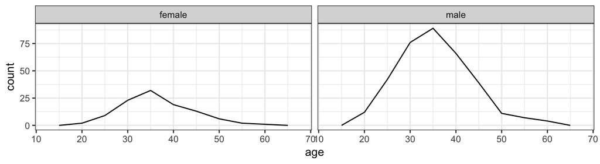

```r
gf_freqpoly( ~ age | sex, data = HELPrct, binwidth = 5)
```

## Facets

- Use `y ~ x | z` to create multipanel plots.

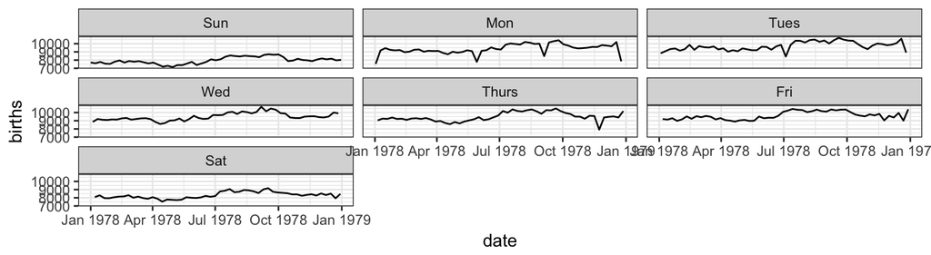

```r
gf_line( births ~ date | wday, data = Births78)
```

## Facets in 2d

- Use `y ~ x | z1 ~ z2` to create a grid of multipanel plots.

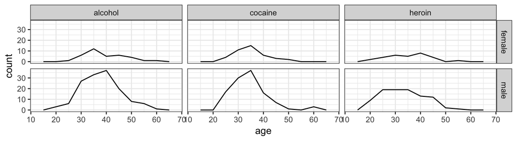

```r
gf_freqpoly( ~ age | sex ~ substance, data = HELPrct, binwidth = 5)
```

## Other attributes

So far we have focused on position, but we can also change attributes like color, size, and shape. Two ways to **map** attributes to variables/exressions:

- `, attribute = ~ expr`
- `+ attribute:variable` (or `attribute::(expression)`) as part of formula

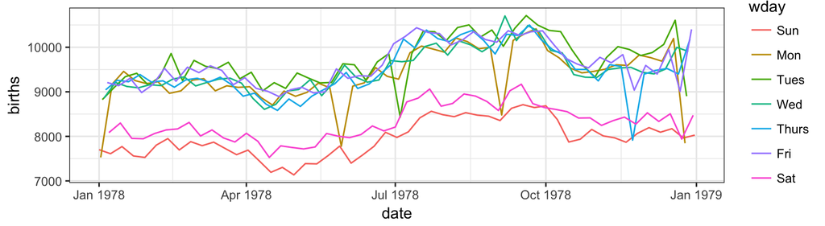

```r
gf_line( births ~ date,  color = ~ wday, data = Births78)
gf_line( births ~ date + color:wday,     data = Births78)
```

## Mix and Match

We can combine attributes and facets.

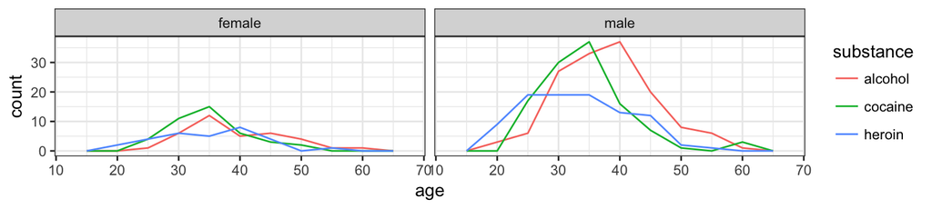

```r
gf_freqpoly( ~ age | sex, data = HELPrct, color = ~ substance, binwidth = 5)
```

## Bells & Whistles

- titles
- axis labels
- fonts and colors for labels
- custom scales (user chosen colors, sizes, etc.)
- etc, etc.

My approach:

- Let the students ask or
- Let the data analysis drive

## Bells & Whistles

This is ugly, but hints at some of the things that can be modified with bells and whistles.

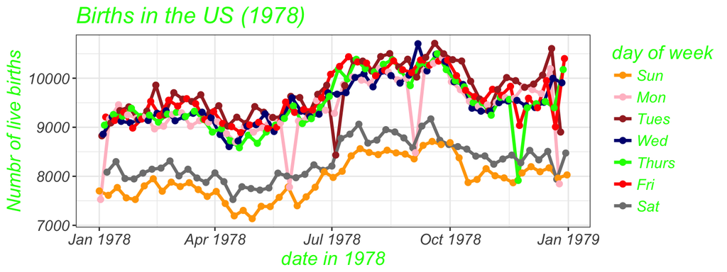

**Note:** The `ggplot2` system, on which `gformula` is built, is based on a notation of layers. It is easy to add multiple layers onto a single plot. In this example, we have layered points and lines (using both `gf_point()` and `gf_line()`). More on this later…

## Numerical Summaries: One Variable

Big idea: Replace plot name with summary name

- Nothing else changes

```
## [1] 35.7
```

[figure not shown]

```r
gf_histogram( ~ age, data = HELPrct)
        mean( ~ age, data = HELPrct )
```

## Other Summaries

The mosaic package includes formula aware versions of `mean()`, `sd()`, `var()`, `min()`, `max()`, `sum()`, `IQR()`, …

Also provides `favstats()` to compute our favorites.

```r
favstats( ~ age, data = HELPrct )
```

```
##  min Q1 median Q3 max mean   sd   n missing
##   19 30     35 40  60 35.7 7.71 453       0
```

## Tallying

```r
tally( ~ sex, data = HELPrct)
```

```
## sex
## female   male
##    107    346
```

```r
tally( ~ substance, data = HELPrct)
```

```
## substance
## alcohol cocaine  heroin
##     177     152     124
```

## Numerical Summaries: Two Variables

Three ways to think about this. All do the same thing.

```r
sd(   age ~ substance, data = HELPrct )
sd( ~ age | substance, data = HELPrct )
sd( ~ age, groups = substance, data = HELPrct )
```

```
## alcohol cocaine  heroin
##    7.65    6.69    7.99
```

## Numerical Summaries: Tables

```r
tally( sex ~ substance, data = HELPrct )
```

```
##         substance
## sex      alcohol cocaine heroin
##   female      36      41     30
##   male       141     111     94
```

```r
tally( ~ sex + substance, data = HELPrct )
```

```
##         substance
## sex      alcohol cocaine heroin
##   female      36      41     30
##   male       141     111     94
```

## Numerical Summaries

```r
mean( age ~ substance | sex, data = HELPrct )
```

```
##  A.F  C.F  H.F  A.M  C.M  H.M    F    M
## 39.2 34.9 34.7 38.0 34.4 33.1 36.3 35.5
```

```r
mean( age ~ substance | sex, data = HELPrct, .format = "table" )
```

```
##   substance sex mean
## 1         A   F 39.2
## 2         A   M   38
## 3         C   F 34.9
## 4         C   M 34.4
## 5         H   F 34.7
## 6         H   M 33.1
```

- I've abbreviated the names to make things fit on slide
- Also works for `median()`, `min()`, `max()`, `sd()`, `var()`, `favstats()`, etc.

## One Template to Rule a Lot

- single and multiple variable graphical summaries
- single and multiple variable numerical summaries
- linear models

```r
      mean( age ~ sex, data = HELPrct )
gf_boxplot( age ~ sex, data = HELPrct )
        lm( age ~ sex, data = HELPrct )
```

```
## female   male
##   36.3   35.5
```

```
## (Intercept)     sexmale
##      36.252      -0.784
```

## Exercises

Answer each question with both a numerical summary and a graphical summary.

1. Are boys feet larger than girls feet? (`KidsFeet`)
2. Do boys and girls differently shaped feet? (`KidsFeet`)

## Getting Oriented to RStudio

## Access to RStudio Sever

- [rstudio.calvin.edu](http://rstudio.calvin.edu:8787)
  - You were sent an email with userid (e.g., rstudio199) and password.
  - [Change passwords here](https://freeipa1.cs.calvin.edu/)

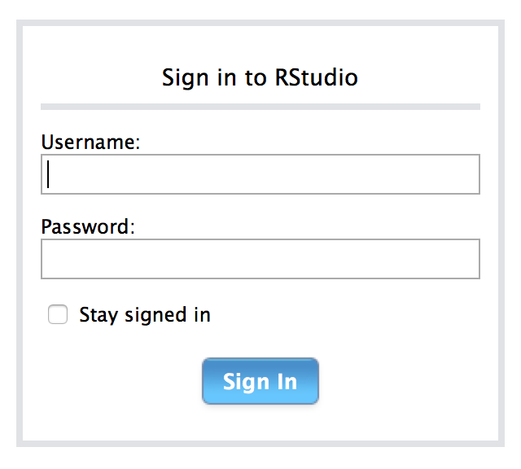

## Menu

- Files, Edit, Code, View, etc.
- Tools > Options for customization

## Panes and Tabs

- 4 **panes** (but some may be minimized).
- Each pane can have multiple **tabs**.
- Options let you decide which tabs go in which panes.

[figure not shown]

## The Console – ephemeral, interactive commands

### R is case sensitive

- many students are *not* case sensitive

### Arrows and Tab

- up/down arrows scroll through history
- TAB completion can simplify typing

### If all else fails, try ESC

- If you see a + prompt, it means R is waiting for more input
- If this is unintentional, you probably have a typo
- ESC will get you pack to the command prompt

## Caclulation and Assignment

- Basic calculation is similar to a calculator
- Results can be stored in named variables with `<-` (or `->`)
- Good place to get started with R (but we will learn other options shortly)

```r
product <- 5 * 3 * 27
product
```

```
## [1] 405
```

```r
sqrt(100)
```

```
## [1] 10
```

```r
log10(product)
```

```
## [1] 2.61
```

## Environment Tab

- Shows the objects in the working environment
- Broom icon clears the working environment

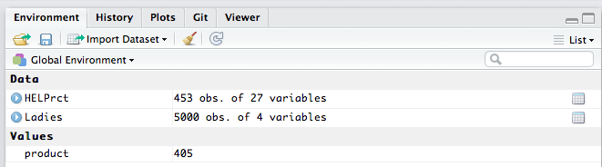

RStudio Environment Tab

## History Tab

- Searchable list of previous commands
- Commands can be copied to console or to files

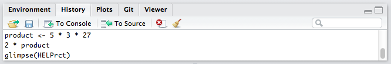

RStudio History Tab

## Packages Tab

- List all installed packages
- Install new packages
- Load/unload packages by clicking check boxes
- Click on name of package to find documentation, vignettes, and other info

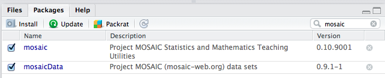

RStudio Packages Tab

## Help!

RStudio provides several ways to get help

- Help tab documents functions and data sets in packages
- `?` followed by name of function or data set
- Package vignettes
- TAB completion provides useful hints

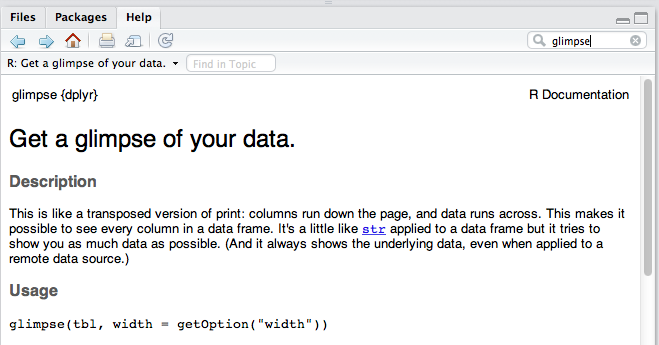

## Some Other Things in mosaic

## Some other things

The `mosaic` package includes some other things, too

- Data sets (you've already seen some of them)
- xtras: `xchisq.test()`, `xpnorm()`, `xqqmath()`
- `mplot()`
- `mplot(HELPrct)` interactive plot creation
- replacements for `plot()` in some situations
- simplified `histogram()` controls (e.g., `width`)
- simplified ways to add onto lattice plots

## xpnorm()

```r
xpnorm( 700, mean = 500, sd = 100)
```

```
##
## If X ~ N(500, 100), then
##
##  P(X <= 700) = P(Z <= 2) = 0.9772
##  P(X >  700) = P(Z >  2) = 0.02275
```

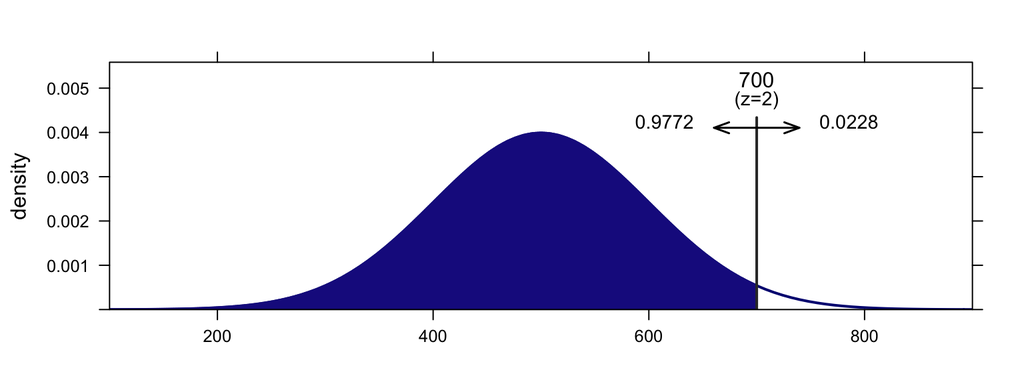

```
## [1] 0.977
```

## xpnorm()

```r
xpnorm( c(300, 700), mean = 500, sd = 100)
```

```
##
## If X ~ N(500, 100), then
##
##  P(X <= 300) = P(Z <= -2) = 0.02275
##      P(X <= 700) = P(Z <=  2) = 0.97725
##  P(X >  300) = P(Z >  -2) = 0.97725
##      P(X >  700) = P(Z >   2) = 0.02275
```

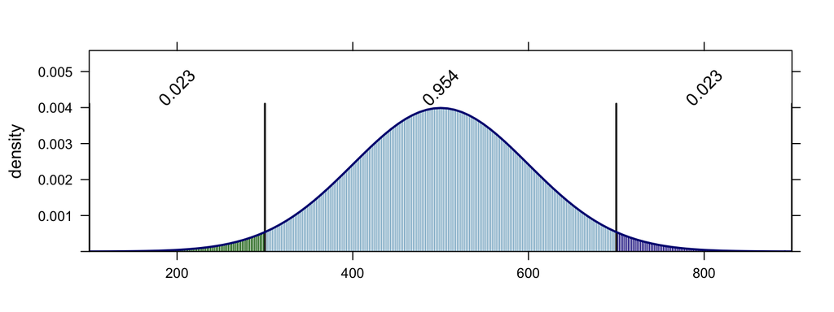

```
## [1] 0.0228 0.9772
```

## xchisq.test()

```r
xchisq.test(phs)
```

[output not shown]

## Modeling

Modeling is really the starting point for the `mosaic` design.

- linear models (`lm()` and `glm()`) defined the template
- `lattice` and `ggformula` graphics use the template (so we chose one of these for plotting)
- we added functionality so numerical summaries can be done with the same template
- additional things added to make modeling easier for beginners.

## Models as Functions

```r
model <- lm(width ~ length * sex, data = KidsFeet)
Width <- makeFun(model)
Width( length = 25, sex = "B")
```

```
##    1
## 9.17
```

```r
Width( length = 25, sex = "G")
```

```
##    1
## 8.94
```

## Models as Functions – Plotting

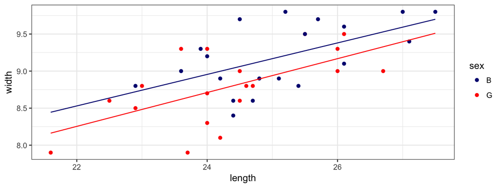

```r
gf_point( width ~ length + color::sex, data = KidsFeet) %>%
  gf_fun(Width(length, sex = "B") ~ length, color = "navy") %>%
  gf_fun(Width(length, sex = "G") ~ length, color = "red") %>%
  gf_refine(scale_color_manual(values = c("navy", "red")))
```

## Resampling – You can do() it!

## Lady Tasting Tea

- Often used on first day of class
- Story
- woman claims she can tell whether milk has been poured into tea or vice versa.
- Question: How do we test this claim?

## Computer Simulation

Use `rflip()` to simulate flipping coins

```r
rflip()
```

```
##
## Flipping 1 coin [ Prob(Heads) = 0.5 ] ...
##
## H
##
## Number of Heads: 1 [Proportion Heads: 1]
```

## Computer Simulation

Faster if we flip multiple coins at once:

```r
rflip(10)
```

```
##
## Flipping 10 coins [ Prob(Heads) = 0.5 ] ...
##
## H H H T T T H H H T
##
## Number of Heads: 6 [Proportion Heads: 0.6]
```

- easier to consider `heads` = correct; `tails` = incorrect than to compare with a given pattern
- this switch bothers me more than it bothers my students

## Let's do that a lot of times

`rflip(10)` simulates 1 lady tasting 10 cups 1 time.

We can do that many times to see how guessing ladies do:

```r
do(2) * rflip(10)
```

```
##    n heads tails prop
## 1 10     6     4  0.6
## 2 10     5     5  0.5
```

- `do()` is clever about what it remembers
- 2 isn't many – we'll do many next.

## The distribution of guessing ladies

```r
Ladies <- do(5000) * rflip(10)
head(Ladies, 1)
```

```
##    n heads tails prop
## 1 10     4     6  0.4
```

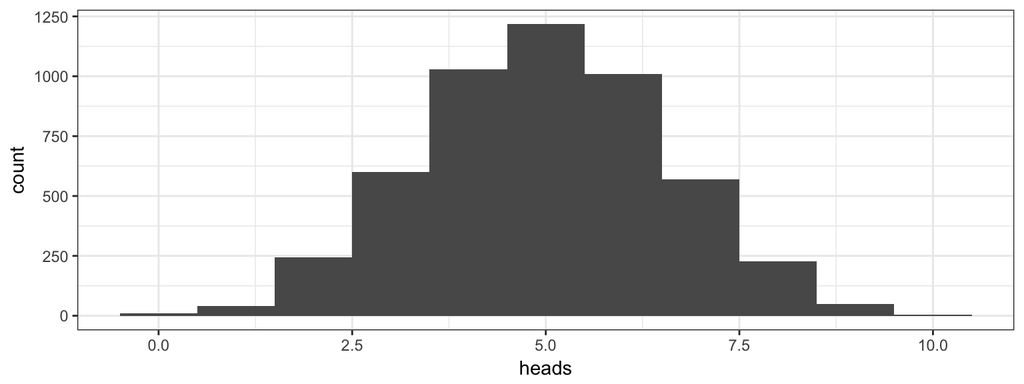

```r
gf_histogram( ~ heads, data = Ladies, binwidth = 1 )
```

## How often does guessing score 9 or 10?

```r
tally( ~ (heads >= 9) , data = Ladies)
```

```
## (heads >= 9)
##  TRUE FALSE
##    52  4948
```

## How often does guessing score 9 or 10?

```r
tally( ~ (heads >= 9) , data = Ladies, format = "prop")
```

```
## (heads >= 9)
##   TRUE  FALSE
## 0.0104 0.9896
```

## How often does guessing score 9 or 10?

```r
tally( ~ (heads >= 9) , data = Ladies, format = "prop")
```

```
## (heads >= 9)
##   TRUE  FALSE
## 0.0104 0.9896
```

```r
 prop( ~ (heads >= 9), data = Ladies)
```

```
##   TRUE
## 0.0104
```

## A general approach to randomization

1. Do it for your data
2. Do it for "random" data
3. Do it lots of times for "random" data
- definition of "random" is important, but can often be handled by `shuffle()` or `resample()`

## Example: Do mean ages differ by sex?

```r
diffmean(age ~ sex, data = HELPrct)
```

```
## diffmean
##   -0.784
```

```r
do(1) *
  diffmean(age ~ shuffle(sex), data = HELPrct)
```

```
##   diffmean
## 1    0.109
```

```r
Null <- do(5000) *
  diffmean(age ~ shuffle(sex), data = HELPrct)
```

## Example: Do mean ages differ by sex?

```r
prop( ~ (abs(diffmean) > 0.7841), data = Null )
```

```
##  TRUE
## 0.362
```

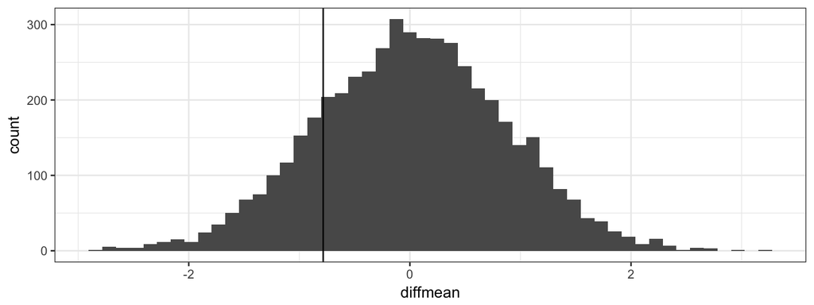

```r
gf_histogram( ~ diffmean, data = Null, bins = 50) %>%
  gf_vline(xintercept = -.7841)
```

## Example: Bootstrap for difference in means

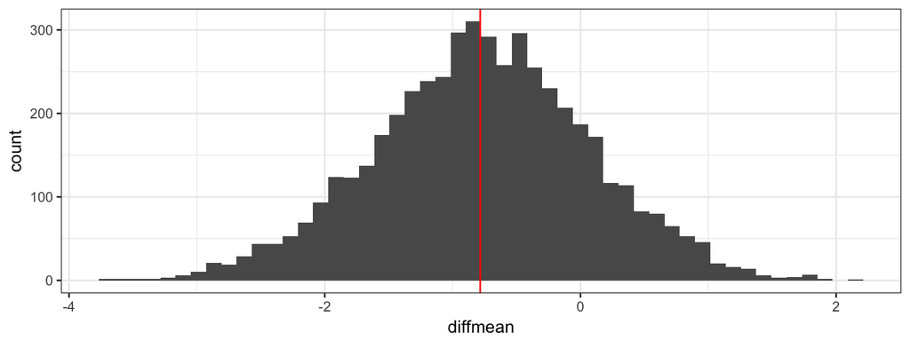

```r
Bootstrap <- do(5000) *
  diffmean(age ~ sex, data= resample(HELPrct))

gf_histogram( ~ diffmean, data = Bootstrap, bins = 50) %>%
  gf_vline(xintercept = -.7841, color = "red")
```

## Example: CI for difference in mean ages

```r
cdata( ~ diffmean, data = Bootstrap, p = .95)
```

```
##       low        hi central.p
##    -2.479     0.889     0.950
```

```r
confint(Bootstrap, method = "quantile")
```

```
##       name lower upper level     method estimate
## 1 diffmean -2.48 0.889  0.95 percentile   -0.784
```

## Example: CI for difference in mean ages

```r
confint(Bootstrap)  # default uses st. err
```

[output not shown]

## Randomization and linear models

```r
do(1) * lm(width ~ length, data = KidsFeet)
```

```
##   Intercept length sigma r.squared    F numdf dendf .row .index
## 1      2.86  0.248 0.396     0.411 25.8     1    37    1      1
```

```r
do(3) * lm( width ~ shuffle(length), data = KidsFeet)
```

```
##   Intercept  length sigma r.squared     F numdf dendf .row .index
## 1     11.64 -0.1071 0.496   0.07664 3.071     1    37    1      1
## 2     11.54 -0.1031 0.498   0.07110 2.832     1    37    1      2
## 3      9.75 -0.0308 0.515   0.00635 0.236     1    37    1      3
```

## Randomization and linear models

```r
do(1) *
  lm(width ~ length + sex, data = KidsFeet)
```

```
##   Intercept length   sexG sigma r.squared    F numdf dendf .row .index
## 1      3.64  0.221 -0.233 0.385      0.46 15.3     2    36    1      1
```

```r
do(3) *
  lm( width ~ length + shuffle(sex), data = KidsFeet)
```

```
##   Intercept length    sexG sigma r.squared    F numdf dendf .row .index
## 1      2.94  0.243  0.0779 0.400     0.417 12.9     2    36    1      1
## 2      3.45  0.228 -0.2083 0.388     0.451 14.8     2    36    1      2
## 3      2.84  0.248  0.0157 0.402     0.411 12.6     2    36    1      3
```

## Randomization and linear models

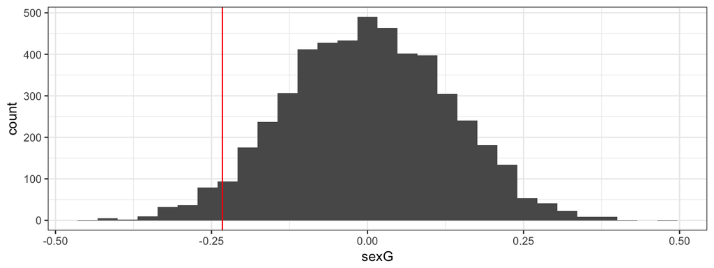

```r
Null <- do(5000) *
  lm( width ~ length + shuffle(sex), data = KidsFeet)
gf_histogram( ~ sexG, data = Null) %>%
  gf_vline(xintercept = -0.2325, color = "red")
```

## Randomization and linear models

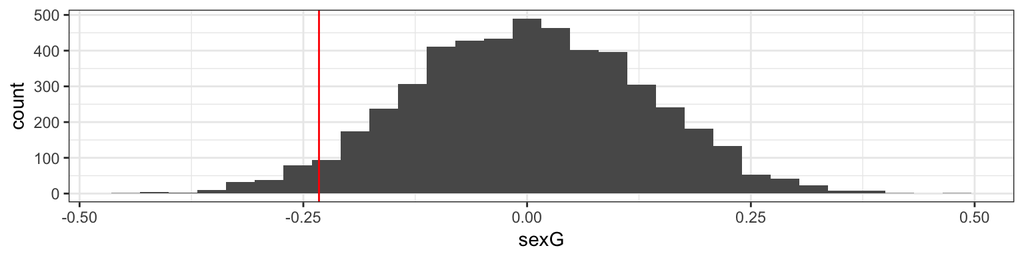

```r
gf_histogram( ~ sexG, data = Null) %>%
  gf_vline(xintercept = -0.2325, color = "red")
```

```r
prop(~ (sexG <= -0.2325), data = Null)
```

```
##  TRUE
## 0.037
```